# Beta-Binomial Model

## Introduction: Beta-Binomial Model

- Last week, we learned how to think like a Bayesian.
  - Today, we will formalize the models we muddled through last time.
- This is called the Beta-Binomial model.
  - The Beta distribution is the *prior*.
  - The Binomial distribution is the *data* distribution (or the *likelihood*).
  - The *posterior* also follows a Beta distribution.
- **Conjugate family**: When the prior and posterior are the same named distribution, but different parameters.

## R Packages Needed

- To follow today’s lecture, please load the following packages:

```r
library(tidyverse)
library(janitor)
library(bayesrules)
library(ggpubr)
```

## Example Set Up

- Consider the following scenario.
  - “Michelle” has decided to run for president and you’re her campaign manager for the state of Florida.
  - As such, you’ve conducted 30 different polls throughout the election season.
  - Though Michelle’s support has hovered around 45%, she polled at around 35% in the dreariest days and around 55% in the best days on the campaign trail.
- Past polls provide prior information about $\pi$, the proportion of Floridians that currently support Michelle.

## Beta Prior

- In building the Bayesian election model of Michelle’s election support among Floridians, $\pi$, we begin with the prior.
  - Our continuous prior probability model of $\pi$ is specified by the probability density function (pdf).
- What values can $\pi$ take and which are more plausible than others?

## Beta Prior

- Let $\pi$ be a random variable, where $\pi \in [0, 1]$.
- The variability in $\pi$ may be captured by a Beta model with hyperparameters $\alpha > 0$ and $\beta > 0$,
  - **hyperparameter:** a parameter used in a *prior* model.

$$\pi \sim \text{Beta}(\alpha, \beta)$$

## Beta Prior: Shapes

- Let’s explore the shape of the Beta:

```r
plot_beta(1, 5) + theme_minimal() + ggtitle("Beta(1, 5)")
```

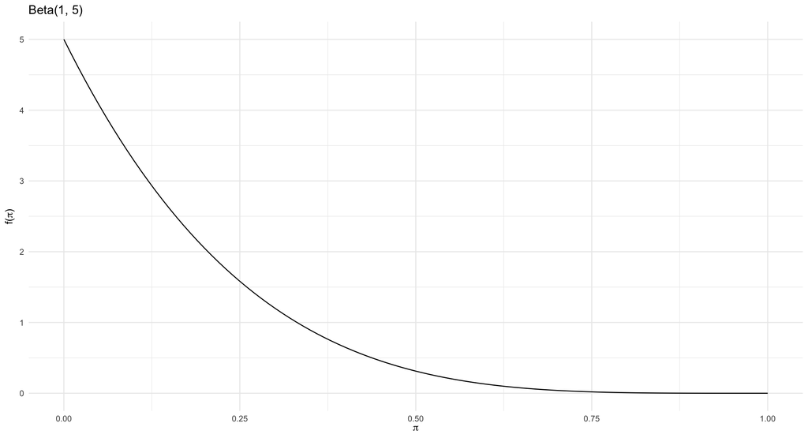

## Beta Prior: Shapes

- Let’s explore the shape of the Beta:

```r
plot_beta(1, 2) + theme_minimal() + ggtitle("Beta(1, 2)")
```

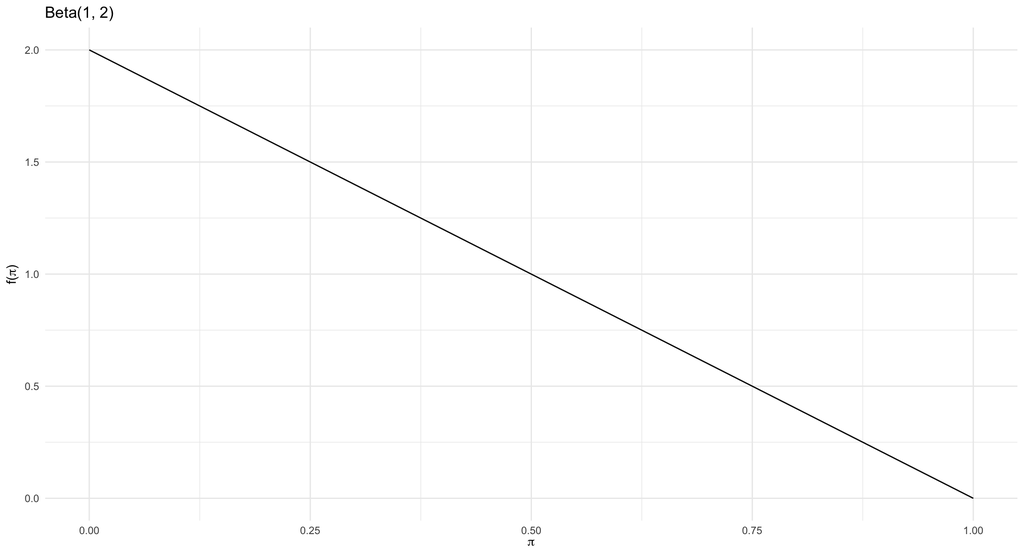

## Beta Prior: Shapes

- Let’s explore the shape of the Beta:

```r
plot_beta(3, 7) + theme_minimal() + ggtitle("Beta(3, 7)")
```

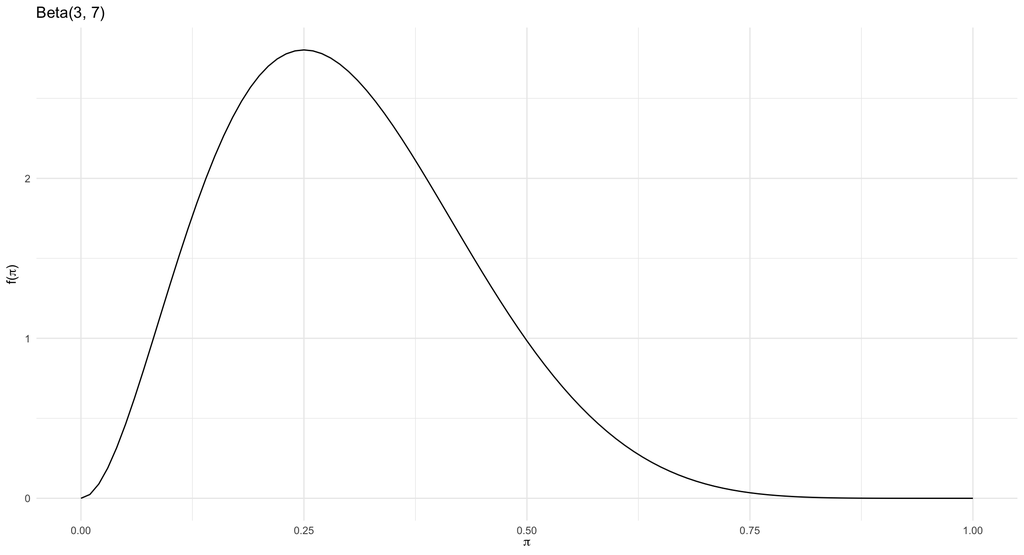

## Beta Prior: Shapes

- Let’s explore the shape of the Beta:

```r
plot_beta(1, 1) + theme_minimal() + ggtitle("Beta(1, 1)")
```

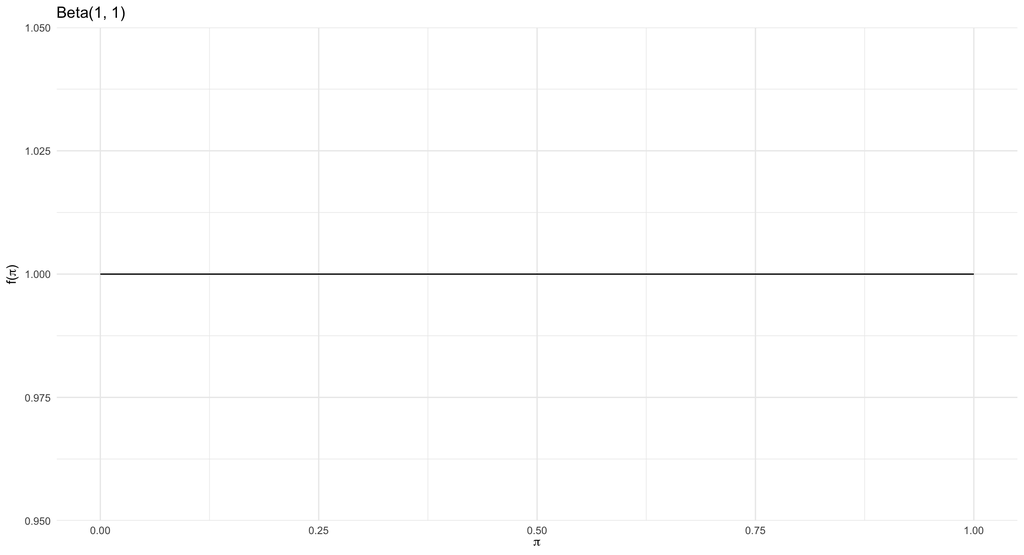

## Beta Prior: Shapes

- Your turn!
- How would you describe the typical behavior of a:
  - Beta($\alpha, \beta$) variable, $\pi$, when $\alpha=\beta$?
  - Beta($\alpha, \beta$) variable, $\pi$, when $\alpha>\beta$?
  - Beta($\alpha, \beta$) variable, $\pi$, when $\alpha<\beta$?
- For which model is there greater variability in the plausible values of $\pi$, Beta(20, 20) or Beta(5, 5)?

## Beta Prior: Shapes

- How would you describe the typical behavior of a Beta($\alpha, \beta$) variable, $\pi$, when $\alpha=\beta$?

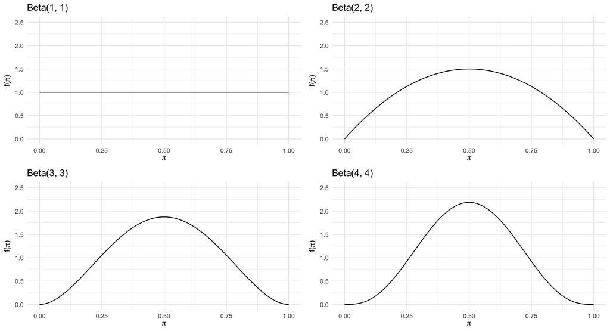

## Beta Prior: Shapes

- How would you describe the typical behavior of a Beta($\alpha, \beta$) variable, $\pi$, when $\alpha>\beta$?

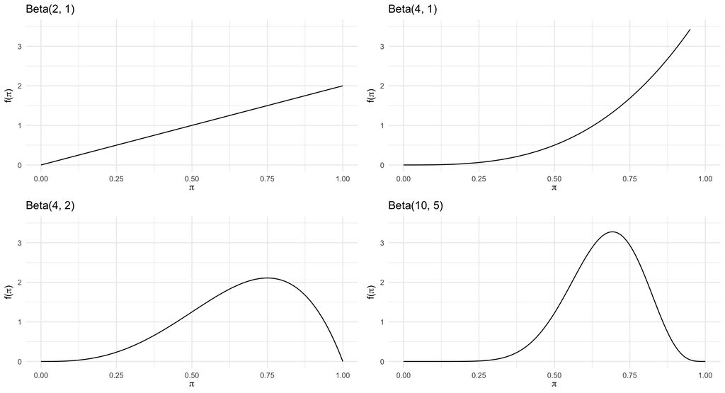

## Beta Prior: Shapes

- How would you describe the typical behavior of a Beta($\alpha, \beta$) variable, $\pi$, when $\alpha<\beta$?

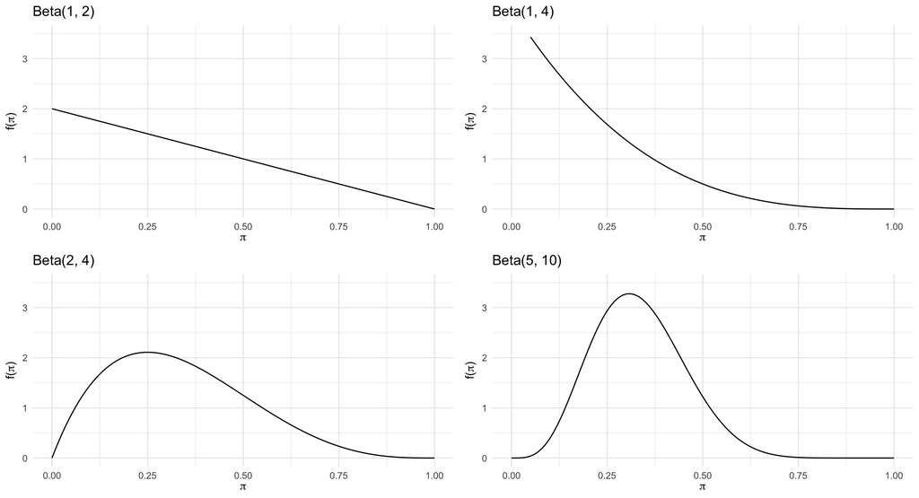

## Beta Prior: Shapes

- For which model is there greater variability in the plausible values of $\pi$, Beta(20, 20) or Beta(5, 5)?

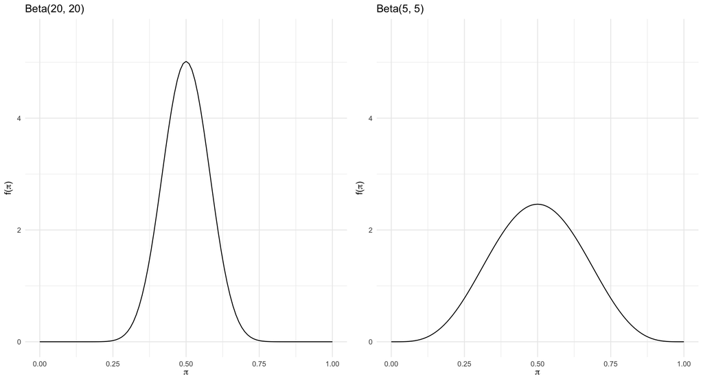

## Tuning the Beta Prior

$$E[\pi] = \frac{\alpha}{\alpha+\beta} \approx 0.45$$

- Using algebra, we can tune, and find

$$\alpha \approx \frac{9}{11} \beta$$

## Tuning the Beta Prior

- Your turn!
  - Graph the following and determine which is best for the example.

```r
plot_beta(9, 11) + theme_minimal() + list(xlim(0, 1), ylim(0, 10))
plot_beta(27, 33) + theme_minimal() + list(xlim(0, 1), ylim(0, 10))
plot_beta(45, 55) + theme_minimal() + list(xlim(0, 1), ylim(0, 10))
```

## Tuning the Beta Prior

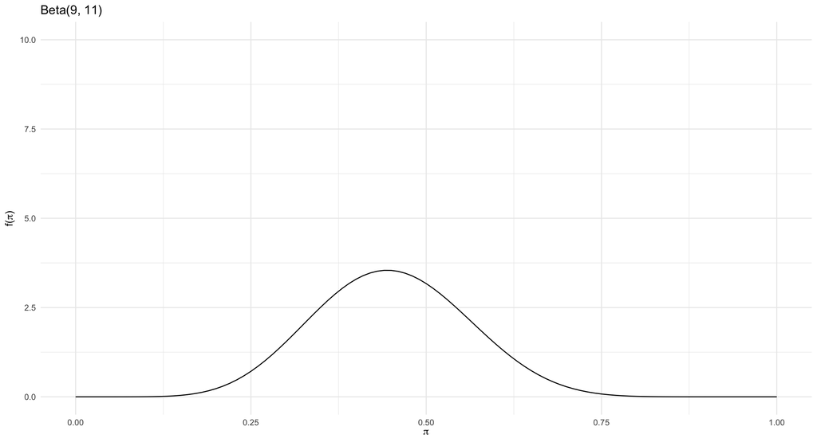

## Tuning the Beta Prior

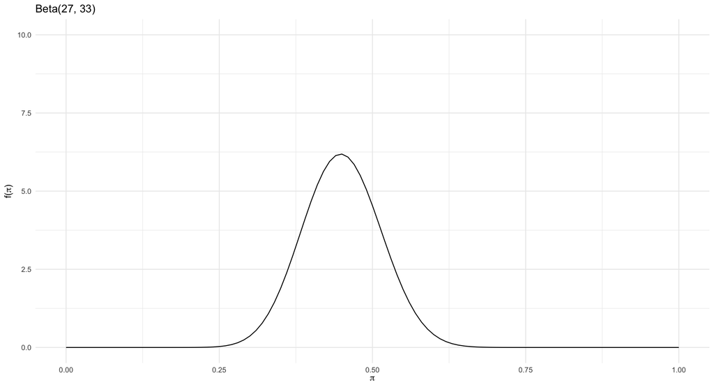

## Tuning the Beta Prior

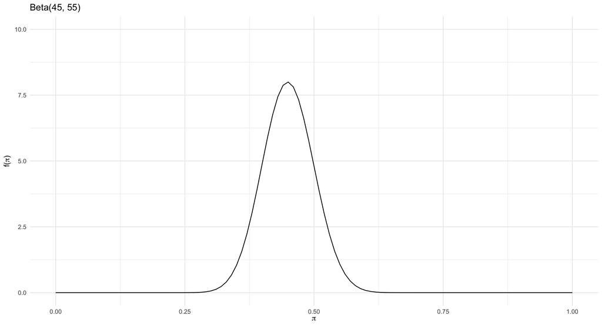

## Tuning the Beta Prior

- Now that we have a prior, we “know” some things.

$$\pi \sim \text{Beta}(45, 55)$$

- From the properties of the beta distribution,

$$\begin{equation*}
\begin{aligned}
E[\pi] &= \frac{\alpha}{\alpha + \beta} & \text{ and } & \text{ } & \text{ } \\
&=\frac{45}{45+55} \\
&= 0.45
\end{aligned}
\begin{aligned}
\text{var}[\pi] &= \frac{\alpha\beta}{(\alpha+\beta)^2(\alpha+\beta+1)} \\
&= \frac{(45)(55)}{(45+55)^2(45+55+1)} \\
&= 0.0025
\end{aligned}
\end{equation*}$$

## Binomial Data Model

- A new poll of $n = 50$ Floridians recorded $Y$, the number that support Michelle.
  - The results depend upon $\pi$ (as $\pi$ increases, $Y$ tends to increase).
- To model the dependence of $Y$ on $\pi$, we assume
  - voters answer the poll independently of one another;
  - the probability that any polled voter supports your candidate Michelle is $\pi$
- This is a binomial event, $Y|\pi \sim \text{Bin}(50, \pi)$, with conditional pmf, $f(y|\pi)$ defined for $y \in \{0, 1, ..., 50\}$

$$f(y|\pi) = P[Y = y|\pi] = {50 \choose y} \pi^y (1-\pi)^{50-y}$$

## Binomial Data Model

- The conditional pmf, $f(y|\pi)$, gives us answers to a hypothetical question:
  - If Michelle’s support were given some value of $\pi$, then how many of the 50 polled voters ($Y=y$) might we expect to support her?
- Let’s look at this graphically:

```r
sample_size <- [value]
pi_value <- [value]
tibble(n_success = 1:sample_size,
       prob = dbinom(n_success,
                     size=sample_size,
                     prob=pi_value)) %>%
  ggplot(aes(x=n_success,y=prob)) +
  geom_col(width=0.2) +
  labs(x= "Number of Successes",
       y= "Probability") +
  theme_minimal()
```

## Binomial Data Model

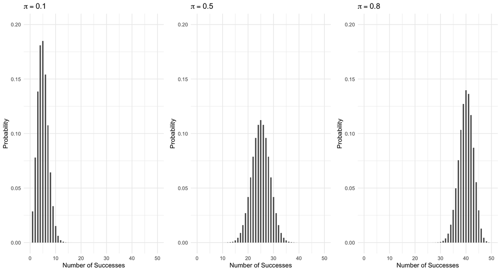

## Binomial Data Model

- It is observed that $Y=30$ of the $n=50$ polled voters support Michelle.
- We now want to find the likelihood function – remember that we treat $Y=30$ as the observed data and $\pi$ as unknown,

$$\begin{align*}
f(y|\pi) &= {50 \choose y} \pi^y (1-\pi)^{50-y} \\
L(\pi|y=30) &= {50 \choose 30} \pi^{30} (1-\pi)^{20}
\end{align*}$$

- This is valid for $\pi \in [0, 1]$.

## Binomial Data Model

- What is the likelihood of 30/50 voters supporting Michelle?

```r
dbinom(30, 50, pi)
```

- You try this for $\pi = \{0.25, 0.50, 0.75\}$.

```r
dbinom(30, 50, 0.25)
dbinom(30, 50, 0.5)
dbinom(30, 50, 0.75)
```

## Binomial Data Model

- What is the likelihood of 30/50 voters supporting Michelle?

```r
dbinom(30, 50, 0.25)
```

```
[1] 1.29633e-07
```

```r
dbinom(30, 50, 0.5)
```

```
[1] 0.04185915
```

```r
dbinom(30, 50, 0.75)
```

```
[1] 0.007654701
```

## Binomial Data Model

- Looking at $\pi$ in a more continuous fashion,

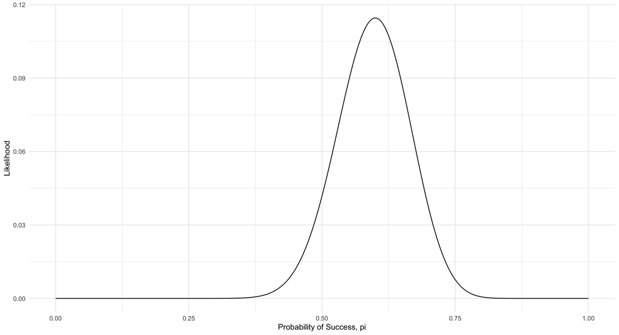

- Where is the maximum?

## Binomial Data Model

- Where is the maximum?

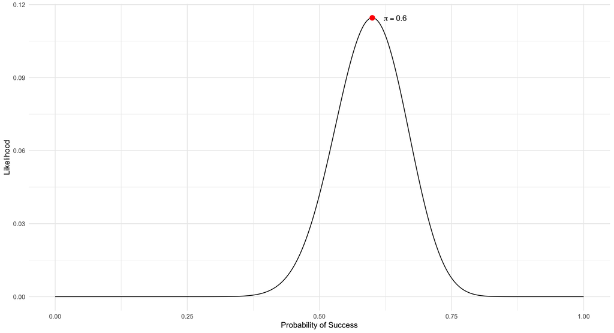

## The Beta Posterior Model

- The `plot_beta_binomial()` function:

```r
plot_beta_binomial(alpha = prior_alpha,
                   beta = prior_beta,
                   y = num_success,
                   n = num_trials,
                   posterior = TRUE or FALSE)
```

- The `summarize_beta_binomial()` function:

```r
summarize_beta_binomial(alpha = prior_alpha,
                        beta = prior_beta,
                        y = num_success,
                        n = num_trials)
```

## The Beta Posterior Model

- Looking at just the prior and the data distributions,

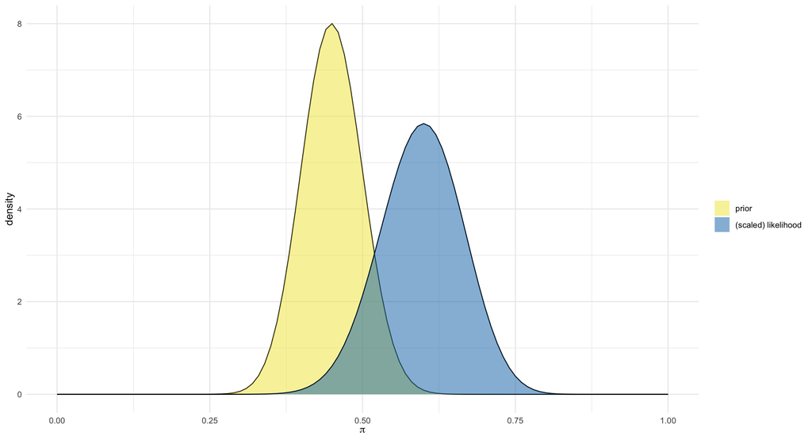

- The prior is a bit more pessimistic about Michelle’s election support than the data obtained from the latest poll.

## The Beta Posterior Model

- Now including the posterior,

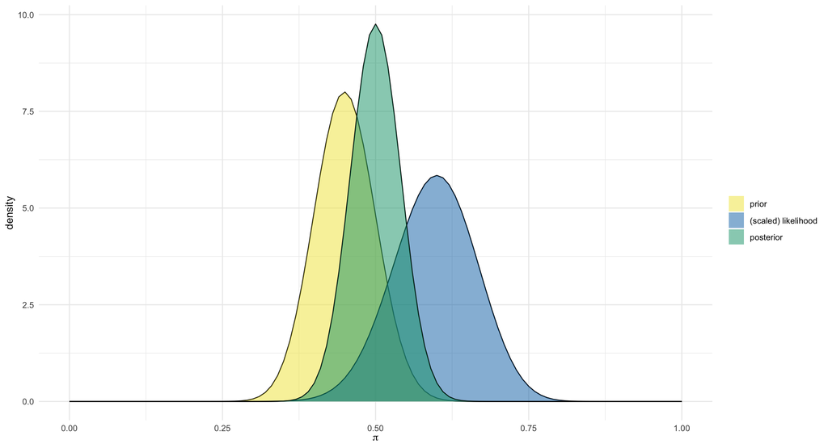

- We can see that the posterior model of $\pi$ is continuous and $\in [0, 1]$.
- The shape of the posterior appears to also have a Beta($\alpha$, $\beta$) model.
  - The shape parameters ($\alpha$ and $\beta$) have been *updated*.

## The Beta Posterior Model

- If we were to collect more information about Michelle’s support, we would use the current posterior as the new prior, then update our posterior.
  - How do we know what the updated parameters are?

```r
summarize_beta_binomial(alpha = 45, beta = 55, y = 30, n = 50)
```

| model | alpha | beta | mean | mode | var | sd |
| --- | --- | --- | --- | --- | --- | --- |
| prior | 45 | 55 | 0.45 | 0.4489796 | 0.0024505 | 0.0495025 |
| posterior | 75 | 75 | 0.50 | 0.5000000 | 0.0016556 | 0.0406894 |

## The Beta Posterior Model

- We used Michelle’s election support to understand the Beta-Binomial model.
- Let’s now generalize it for any appropriate situation.

$$\begin{align*}
Y|\pi &\sim \text{Bin}(n, \pi) \\
\pi &\sim \text{Beta}(\alpha, \beta) \\
\pi | (Y=y) &\sim \text{Beta}(\alpha+y, \beta+n-y)
\end{align*}$$

- We can see that the posterior distribution reveals the influence of the prior ($\alpha$ and $\beta$) and data ($y$ and $n$).

## The Beta Posterior Model

- Under this updated distribution,

$$\pi | (Y=y) \sim \text{Beta}(\alpha+y, \beta+n-y)$$

- we have updated moments:

$$\begin{align*}
E[\pi | Y = y] &= \frac{\alpha + y}{\alpha + \beta + n} \\
\text{Var}[\pi|Y=y] &= \frac{(\alpha+y)(\beta+n-y)}{(\alpha+\beta+n)^2(\alpha+\beta+n+1)}
\end{align*}$$

## The Beta Posterior Model

- Let’s pause and think about this from a theoretical standpoint.
- The Beta distribution is a *conjugate prior* for the likelihood.
  - **Conjugate prior**: the posterior is from the same model family as the prior.
- Recall the Beta prior, $f(\pi)$,

$$f(\pi) = \frac{\Gamma(\alpha+\beta)}{\Gamma(\alpha)\Gamma(\beta)} \pi^{\alpha-1}(1-\pi)^{\beta-1},$$

- and the likelihood function, $L(\pi|y)$,

$$L(\pi|y) = {n \choose y} \pi^y (1-\pi)^{n-y}$$

## The Beta Posterior Model

- We can put the prior and likelihood together to create the posterior,

$$\begin{align*}
f(\pi|y) &\propto f(\pi)L(\pi|y) \\
&= \frac{\Gamma(\alpha+\beta)}{\Gamma(\alpha)\Gamma(\beta)} \pi^{\alpha-1}(1-\pi)^{\beta-1} \times {n \choose y} \pi^y (1-\pi)^{n-y} \\
&\propto \pi^{(\alpha+y)-1} (1-\pi)^{(\beta+n-y)-1}
\end{align*}$$

- This is the same structure as the normalized Beta($\alpha+y, \beta+n-y$),

$$f(\pi|y) = \frac{\Gamma(\alpha+\beta+n)}{\Gamma(\alpha+y) \Gamma(\beta+n-y)} \pi^{(\alpha+y)-1} (1-\pi)^{(\beta+n-y)-1}$$

## Beta-Binomial: Example

- In Mario Kart 8 Deluxe, item boxes give different items depending on race position. To reduce the “position bias,” only item boxes opened while the racer was in mid-pack (positions 4–10) were recorded.
- You want to estimate the probability that an item box yields a Red Shell. When playing the Special Cup, only 31 red shells were seen in 114 boxes opened by mid-pack racers.
- Find the posterior distribution under two priors:
  1. Flat/uninformative prior, Beta(1,1).
  2. Beta($\alpha$, $\beta$) of your choosing.

## Wrap Up: Beta-Binomial Model

- We have built the Beta-Binomial model for $\pi$, an unknown proportion.

$$\begin{equation*}
\begin{aligned}
Y|\pi &\sim \text{Bin}(n,\pi) \\
\pi &\sim \text{Beta}(\alpha,\beta) &
\end{aligned}
\Rightarrow
\begin{aligned}
&& \pi | (Y=y) &\sim \text{Beta}(\alpha+y, \beta+n-y) \\
\end{aligned}
\end{equation*}$$

- The prior model, $f(\pi)$, is given by Beta($\alpha,\beta$).
- The data model, $f(Y|\pi)$, is given by Bin($n,\pi$).
- The likelihood function, $L(\pi|y)$, is obtained by plugging $y$ into the Binomial pmf.
- The posterior model is a Beta distribution with updated parameters $\alpha+y$ and $\beta+n-y$.

## Wrap Up

- Today we covered Beta-Binomial *conjugate family*.
  - Beta-Binomial: binary outcomes
- Next week:
  - Gamma-Poisson: count outcomes
  - Normal-Normal: continuous outcomes